# Observer’s paradox: data from the interviews in the Ustja River Basin Corpus

*Author: Alexey Koshevoy (supervized by Michael Daniel)*

## Other parts of the project:

- [Preprocessing](https://github.com/alexeykosh/diploma/blob/master/calcs/data_preprocessing.ipynb)

## Data description

The data used in this study is a subset of the data from the Ustja River Basin corpus (see von Waldenfels et al., 2014). It is a moderately small dialectal corpora (around 215.000 tokens, of which around 180.000 belongs to speakers of the Ustja dialect of Russian language). The dataset used in this project contains a sample of 178 interviews from the corpora (belonging to 135 different speakers), which were annotated by different people in order to retrieve information about particular variables – 14 in total, concerning primarily phonetics (see full list in Daniel et al., in press). The main information that was stored about a particular variable at a particular timestamp, is whether it has dialectal realization or not. The overall dataframe contains 24.563 recordings.

```
## [1] "ru_RU/ru_RU/ru_RU/C/ru_RU/C"
```

```
## [1] 2344302 2357498
```

### Year of birth

The year of birth is distributed as follows:

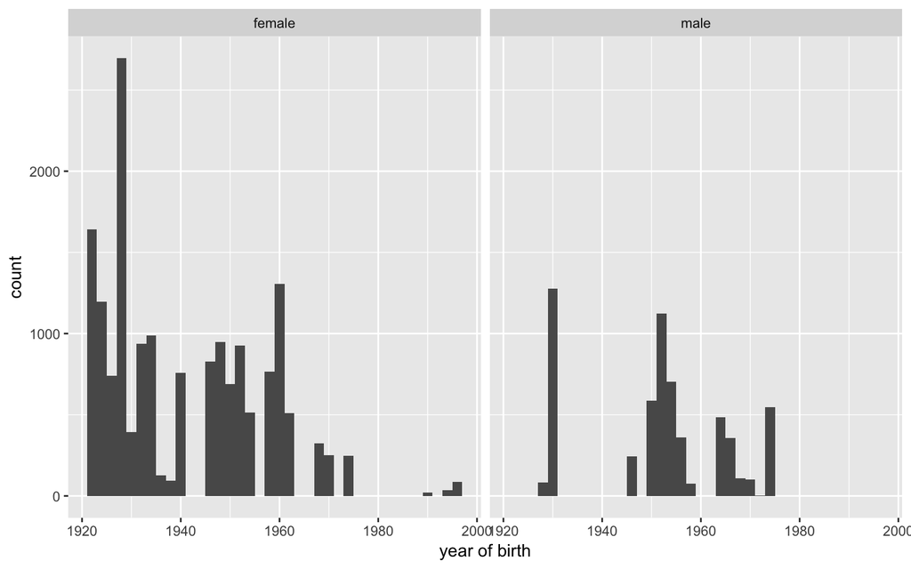

### Variables:

For example:

- A~E: raising of /a/. In the dialect, stressed /a/ has been between palatalized consonants raised to /e/; in the standard, /a/ is retained in this position.
- E~I: raising of yat . In the dialect, stressed etymological (known as yat; assumed pronunciation close mid [??] or diphthong [ie]) between palatalized consonants has been raised to /i/, while in the standard, it has merged with /e/

Distribution of observations per variable across genders:

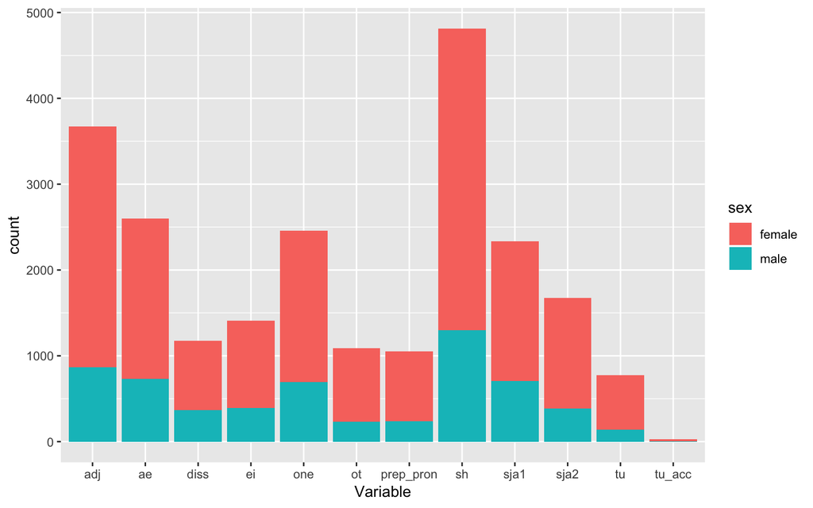

Examination of the lengths of the files (median in red)

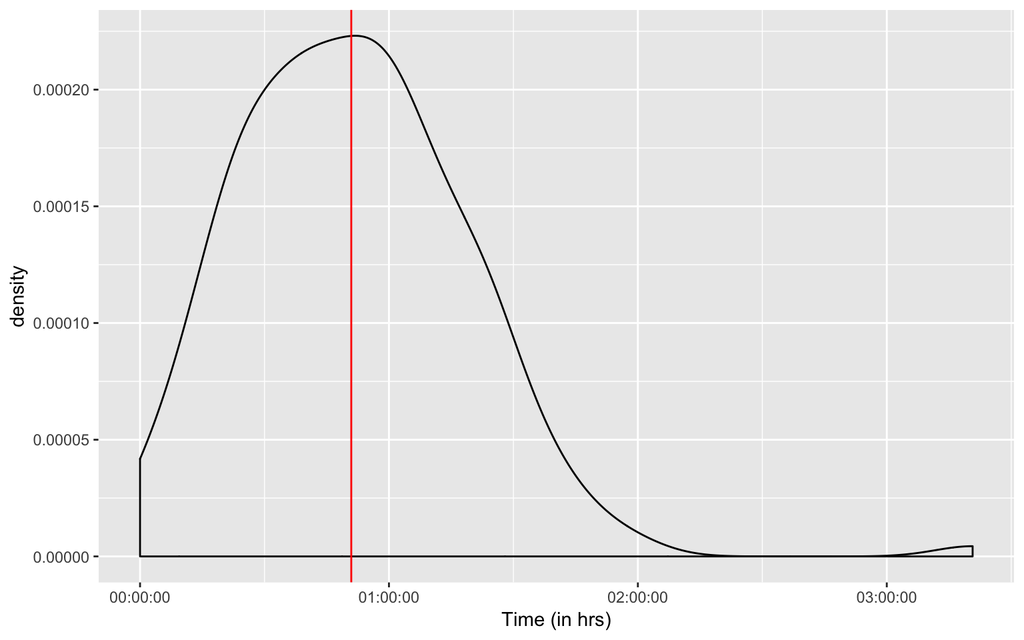

Year of birth and realization class corelation (younger people tent to be less dialect):

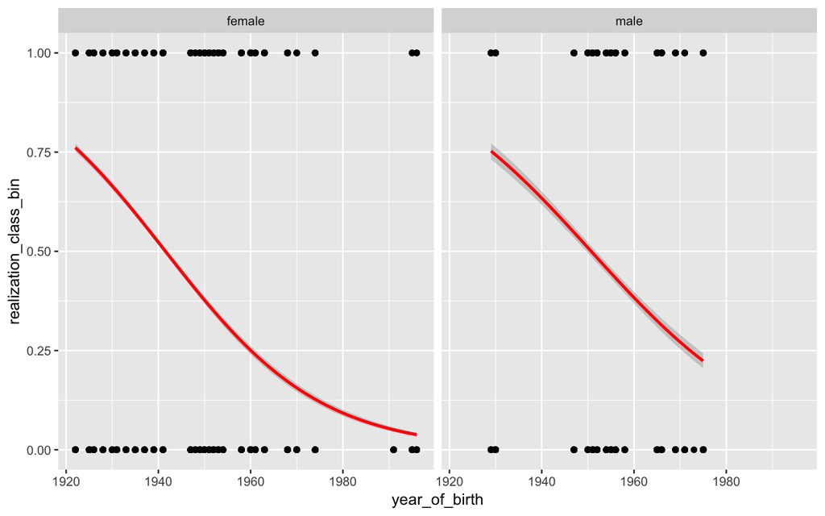

## Analysis: shuffling

### Examples

Example plot:

```r
first_part <-  c(0, 0, 0, 1, 0, 0)
second_part <-  c(1, 1, 1, 1, 1, 1, 0, 0, 0, 1, 1, 1, 1, 1, 1, 1, 1, 1, 1, 1, 1)

mean(first_part)
```

```
## [1] 0.1666667
```

```r
mean(second_part)
```

```
## [1] 0.8571429
```

```r
mean(first_part) - mean(second_part)
```

```
## [1] -0.6904762
```

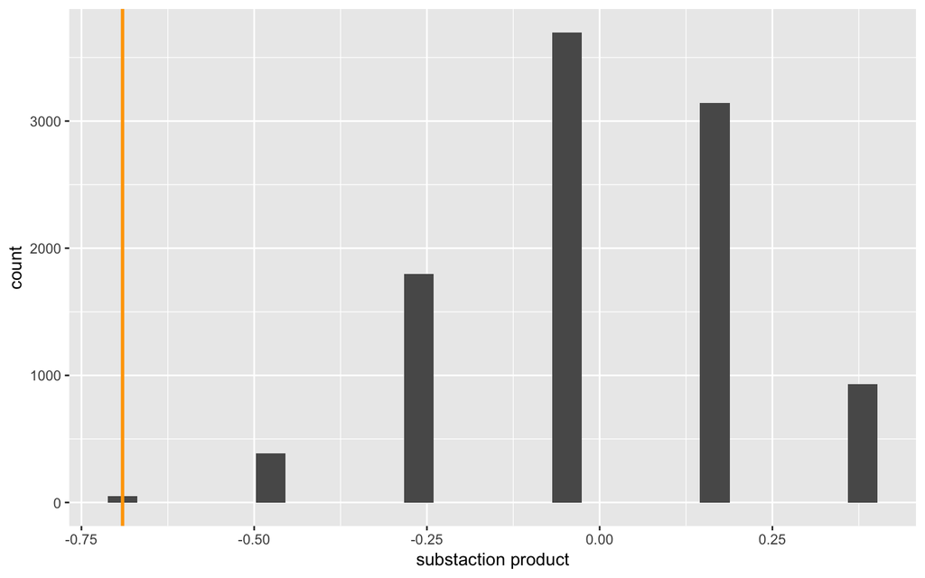

Function for the first experiment:

```r
first_test <- function(subset, n=10000, filename='none', var='none'){

  subtr <- c()


  first_part <-  subset[subset$position < 600000,]$realization_class_bin
  second_part <-  subset[subset$position > 600000*3,]$realization_class_bin

  if (length(first_part) >= 5 && length(second_part) >= 5){

    all_entries <- c(first_part, second_part)

    true_val <- mean(first_part) - mean(second_part)

    print(true_val)

    for (i in c(1:n)){

      all_entries <- sample(all_entries)

      first_part_shaken <- all_entries[1:length(first_part)]

      second_part_shaken <- tail(all_entries, -length(first_part))

      subtr <- c(subtr, mean(first_part_shaken) - mean(second_part_shaken))

    }

    ggplot()+
    aes(subtr)+
    geom_bar()+
    xlab('substaction product')+
    ggtitle(filename)+
    geom_vline(xintercept = true_val, color = "orange", size=1)

  }

}
```

Example (file – 20160624c-nfm, variable – sh):

```
## [1] -0.4509804
```

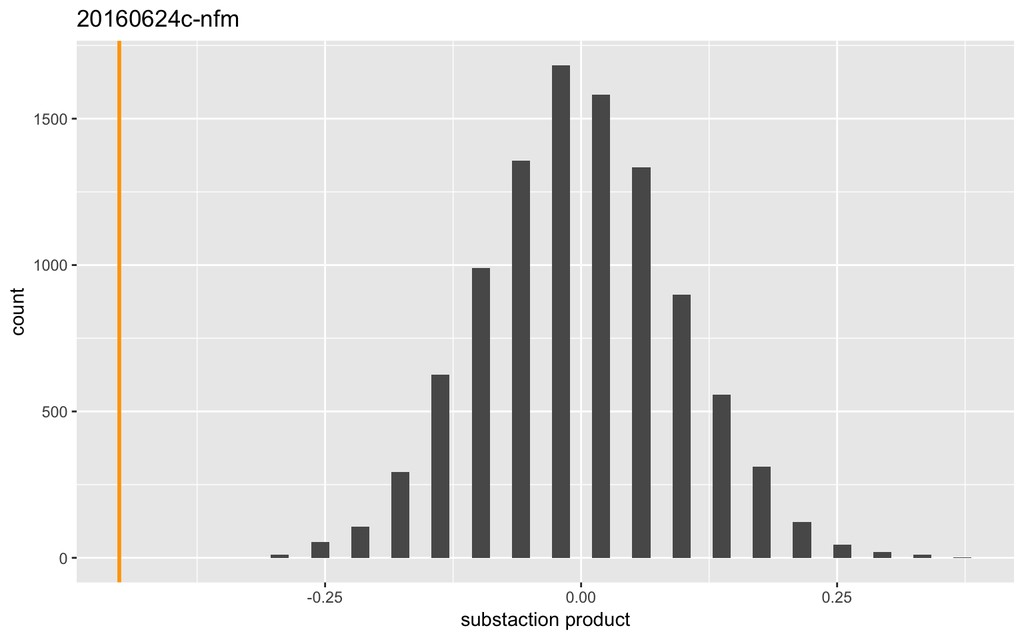

Second test (if first test has shown significance):

```r
second_test <- function(substs, n=10000, name='none', var='none'){

  ks <- c()

  first_part <-  substs[substs$position < 600000,]$realization_class_bin

  second_part <-  substs[substs$position > 600000*3,]$realization_class_bin

  for (i in c(1:n)){
    k = sample(first_part, 1) - sample(second_part, 1)

    ks <- c(ks, k)
  }


  ggplot(as.data.frame(table(ks)), aes(x=names(table(ks)), y = Freq)) +
    geom_bar(stat="identity")+
    xlab('substraction product')+
    ggtitle(paste(var, name, 'first part mean', mean(first_part), 'second part mean', mean(second_part), 'quantities:', length(first_part), length(second_part), sep=' '))

}
```

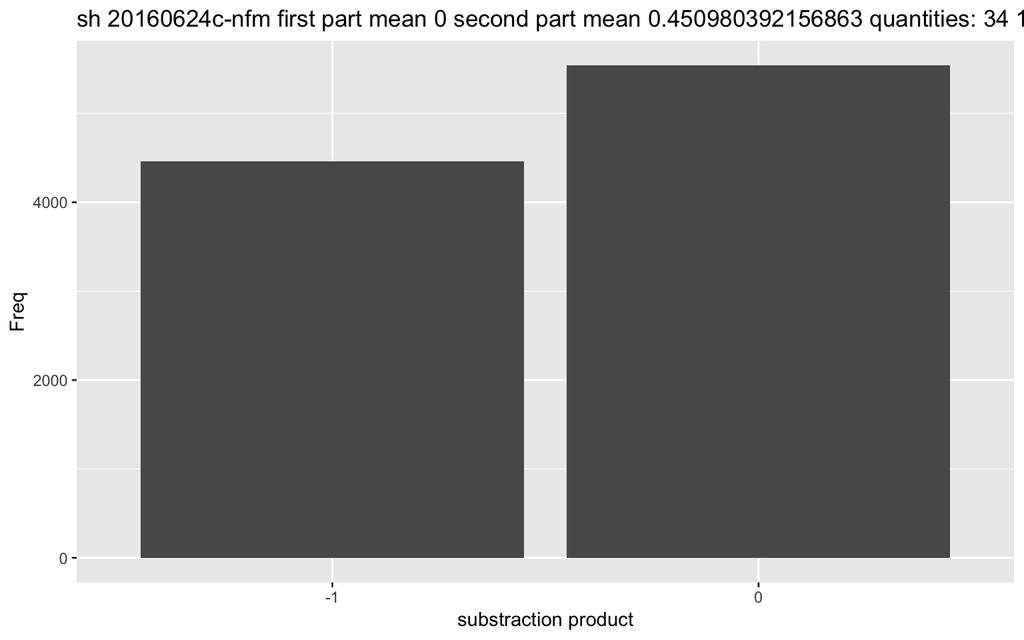

### Results

#### Adj

- 20140624e-lso

```r
first_test(subset = data[data$audio == "20140624e-lso" & data$var == 'adj',], filename='20140624e-lso', var='sh')
```

```
## [1] -0.3111111
```

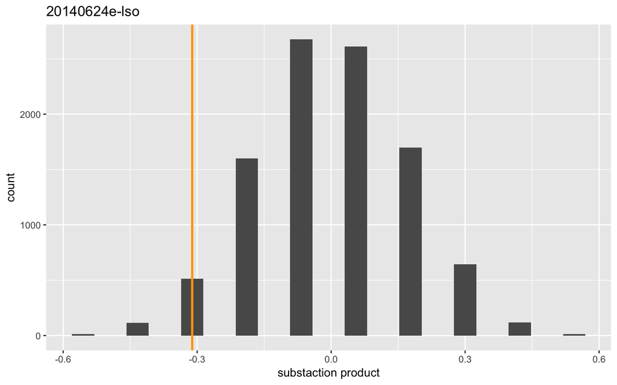

- 20130702b-nvt

```r
first_test(subset = data[data$audio == "20130702b-nvt" & data$var == 'adj',], filename='20140624e-lso', var='sh')
```

```
## [1] -0.3589744
```

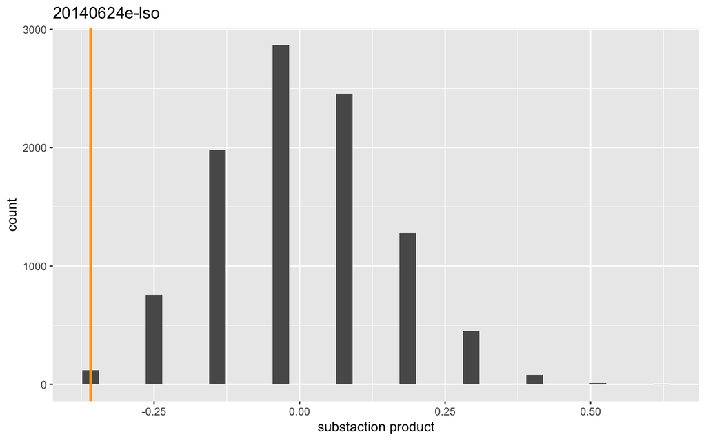

- 20130701d-avm

```r
first_test(subset = data[data$audio == "20130701d-avm" & data$var == 'adj',], filename='20130701d-avm', var='sh')
```

```
## [1] 0.4880952
```

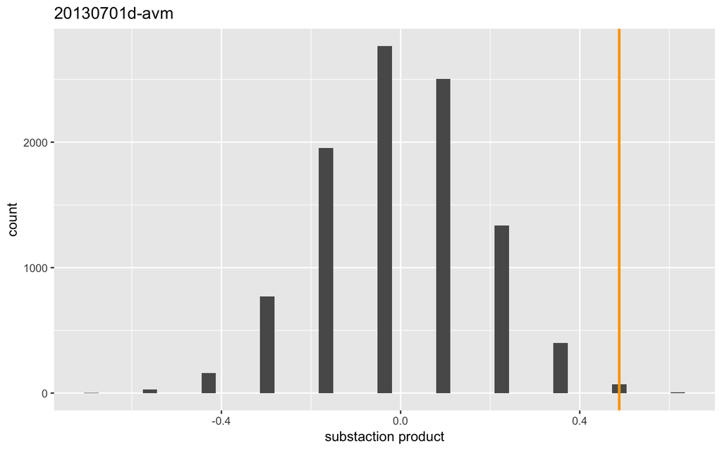

- 20140626c-npo-1

```r
first_test(subset = data[data$audio == "20140626c-npo-1" & data$var == 'adj',], filename='20140626c-npo-1', var='sh')
```

```
## [1] 0.5
```

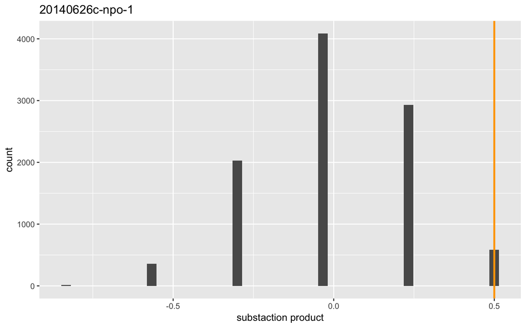

- 20150715a-nnt-1

```r
first_test(subset = data[data$audio == "20150715a-nnt-1" & data$var == 'adj',], filename='20150715a-nnt-1', var='sh')
```

```
## [1] 0.1764706
```

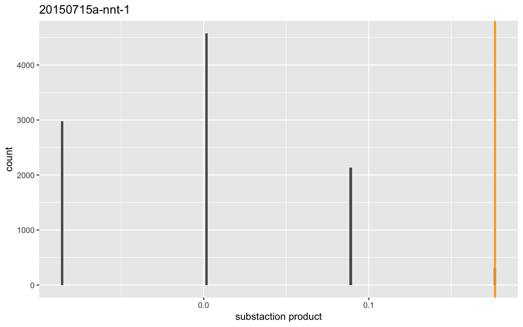

- I20130623b1

```r
first_test(subset = data[data$audio == "I20130623b1" & data$var == 'adj',], filename='I20130623b1', var='sh')
```

```
## [1] -0.625
```

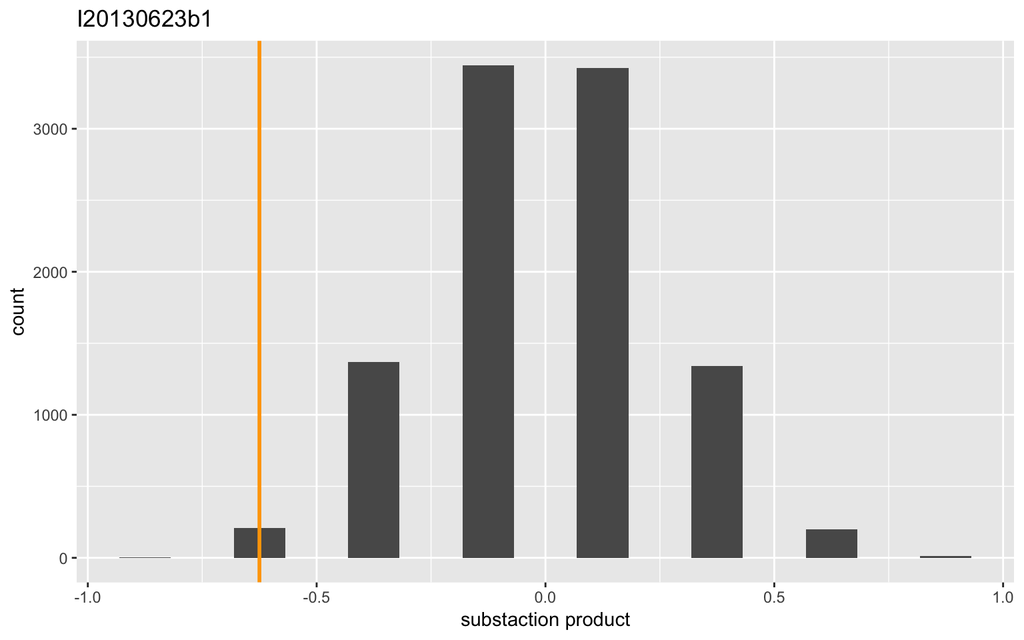

- 20160624c-nfm

```r
first_test(subset = data[data$audio == "20160624c-nfm" & data$var == 'adj',], filename='20160624c-nfm', var='sh')
```

```
## [1] 0.2857143
```

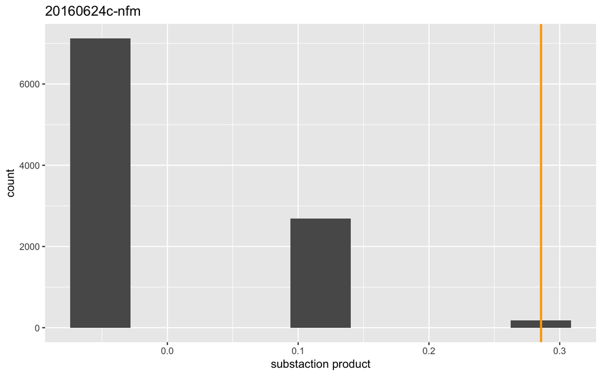

#### Sja-1

- 20140704e-lso-2

```r
first_test(subset = data[data$audio == "20140704e-lso-2" & data$var == 'adj',], filename='20140704e-lso-2')
```

```
## [1] -0.2285714
```

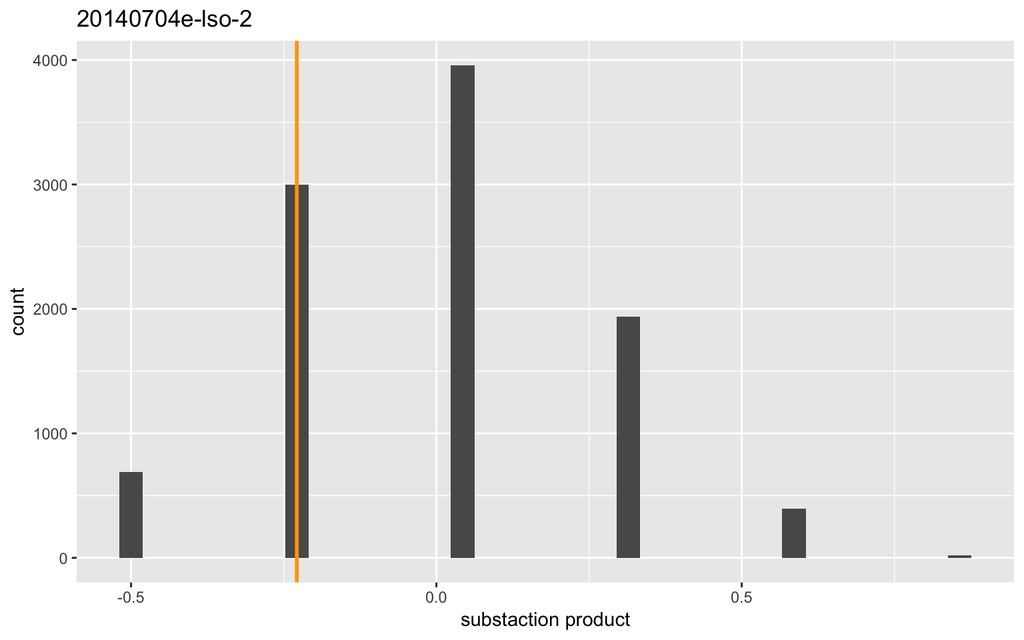

#### prep_pron

- 20130701d-avm

```r
first_test(subset = data[data$audio == "20130701d-avm" & data$var == 'adj',], filename='20130701d-avm')
```

```
## [1] 0.4880952
```

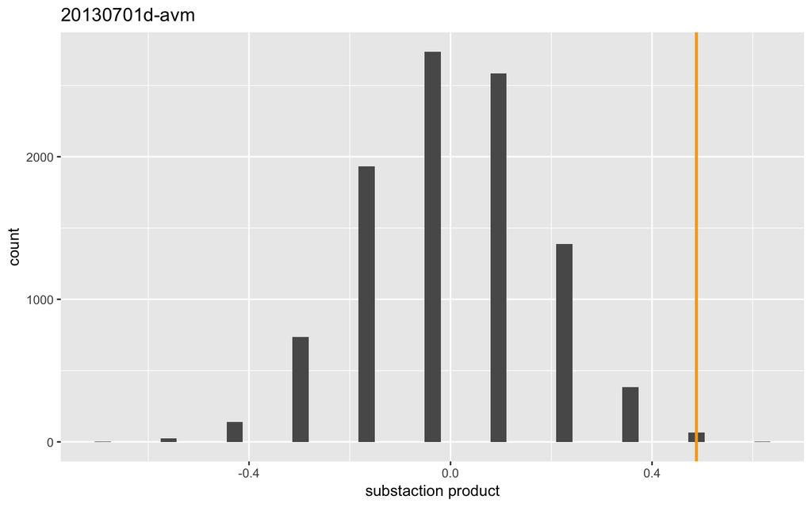

#### ot

- 20150712a-ops-1

```r
first_test(subset = data[data$audio == "20150712a-opsh-1" & data$var == 'ot',], filename='20150712a-opsh-1')
```

```
## [1] -0.375
```

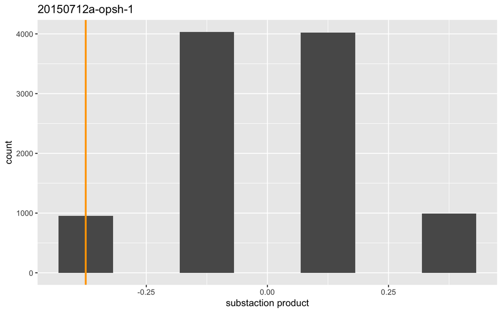

#### ei

- 20130704c-lpp

```r
first_test(subset = data[data$audio == "20130704c-lpp" & data$var == 'ei',], filename='20130704c-lpp')
```

```
## [1] 0.625
```

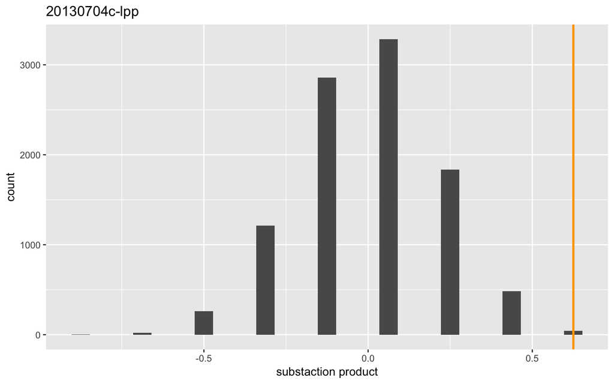

- 20130701c-epr

```r
first_test(subset = data[data$audio == "20130701c-epr" & data$var == 'ei',], filename='20130701c-epr')
```

```
## [1] -0.5
```

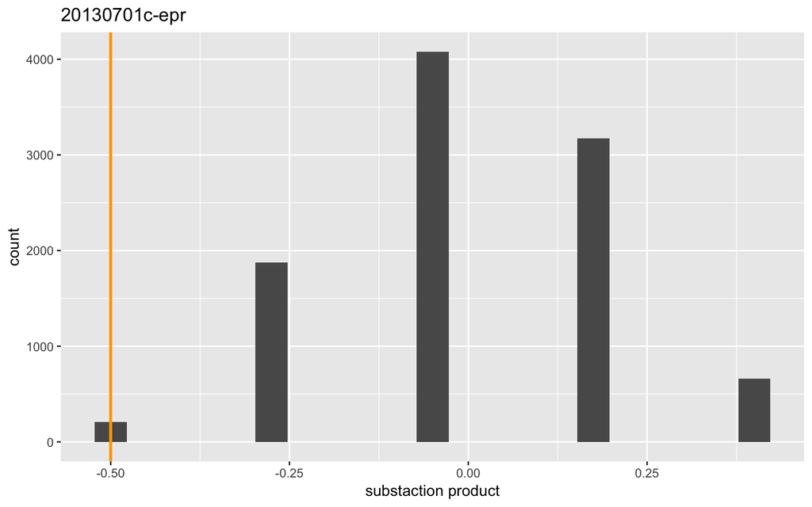

#### sh

- 20130702b-nvt

```r
first_test(subset = data[data$audio == "20130702b-nvt" & data$var == 'sh',], filename='20130702b-nvt')
```

```
## [1] -0.125
```

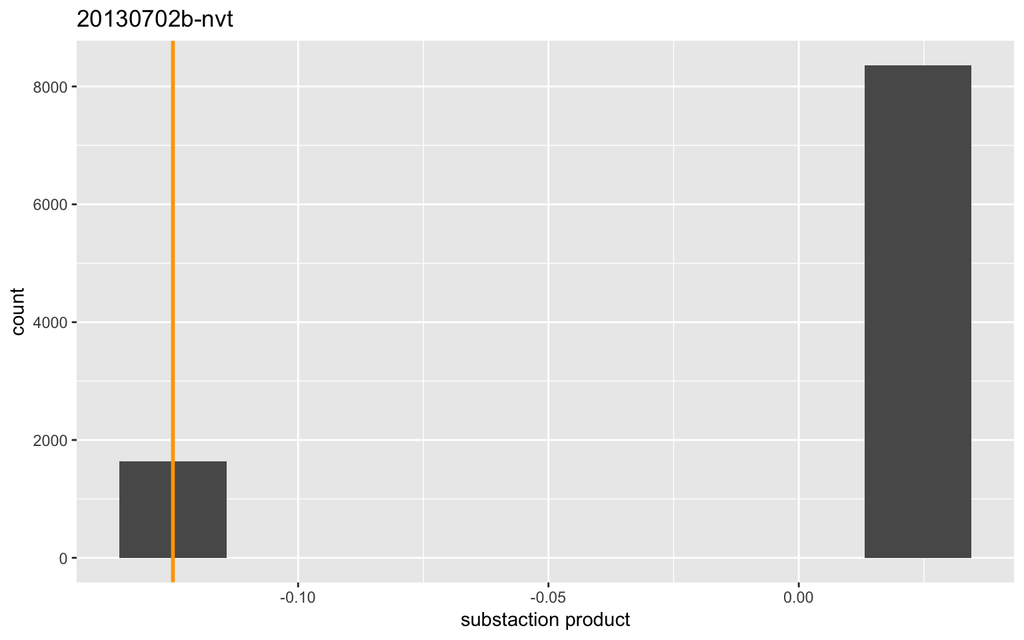

- 20150716b-sek-1

```r
first_test(subset = data[data$audio == "20150716b-sek-1" & data$var == 'sh',], filename='20150716b-sek-1')
```

```
## [1] -0.3194444
```

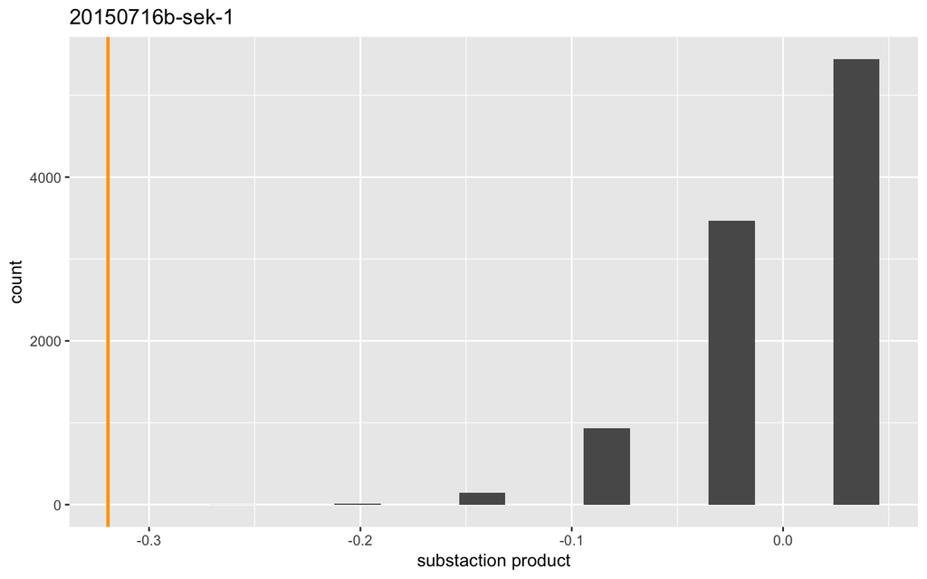

- 20160624c-nfm

```r
first_test(subset = data[data$audio == "20160624c-nfm" & data$var == 'sh',], filename='20160624c-nfm')
```

```
## [1] -0.4509804
```

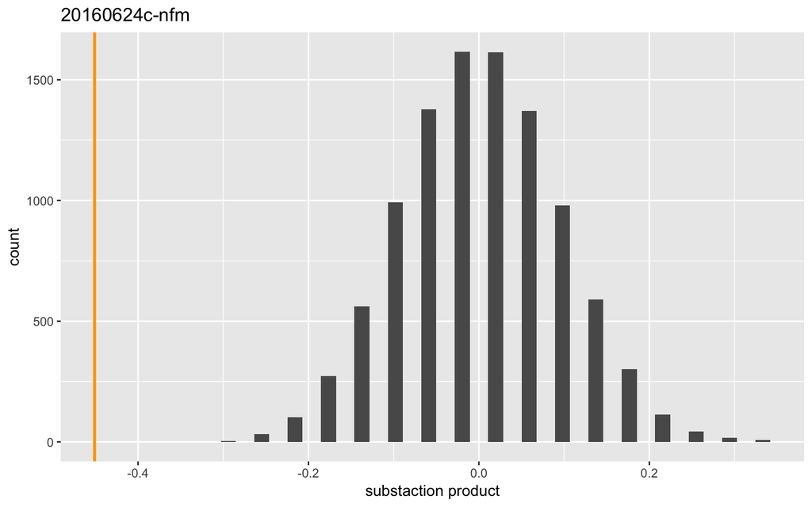

- 20160630g-ans-1

```r
first_test(subset = data[data$audio == "20160630g-ans-1" & data$var == 'sh',], filename='20160630g-ans-1')
```

```
## [1] -0.25
```

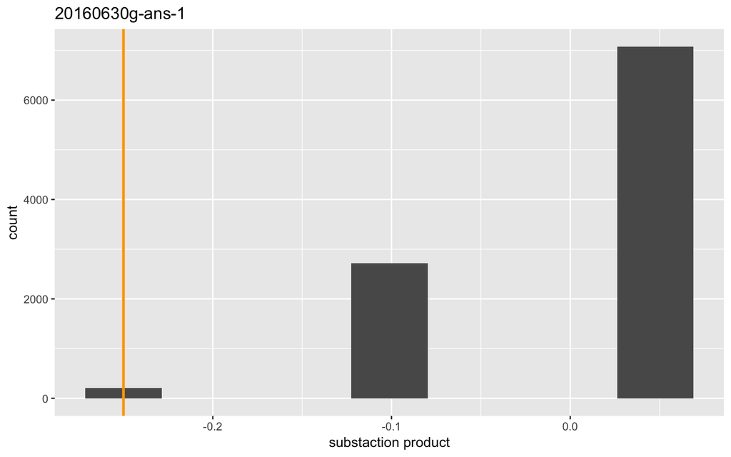

## Analysis: Generalized Linear Models

### All the data

Best model choise:

```r
model1 <- glm(realization_class_bin ~ scale(position), data=data, family = binomial)

model2 <- glmer(realization_class_bin ~ scale(position) + (1 | audio/sex/speaker) + (1 | token/var) + (1 | age_group), family = binomial, data=data)

model3 <- glmer(realization_class_bin ~ scale(position) + (1 | audio/sex/speaker) + (1 | token/var) + (1 | year_of_birth), family = binomial, data=data)

model4 <- glmer(realization_class_bin ~ scale(position) + (1 | sex/speaker) + (1 | token/var) + (1 | age_group) + (1 | audio), family = binomial, data=data)

model5 <- glmer(realization_class_bin ~ scale(position) + (1 | sex/speaker) + (1 | token/var) + (1 | year_of_birth) + (1 | audio), family = binomial, data=data)

model6 <- glmer(realization_class_bin ~ scale(position) + (1 | audio/sex/speaker/year_of_birth) + (1 | token/var), family = binomial, data=data)

model7 <- glmer(realization_class_bin ~ scale(position) + (1 | audio/sex/speaker/age_group) + (1 | token/var), family = binomial, data=data)


AIC(model1)
```

```
## [1] 31989.3
```

```r
AIC(model2)
```

```
## [1] 20453.47
```

```r
AIC(model3)
```

```
## [1] 20460.87
```

```r
AIC(model4)
```

```
## [1] 20351.54
```

```r
AIC(model5)
```

```
## [1] 20382.42
```

```r
AIC(model6)
```

```
## [1] 20577.43
```

```r
AIC(model7)
```

```
## [1] 20577.43
```

```r
model_all <- glmer(realization_class_bin ~ scale(position) + (1 | sex/speaker) + (1 | token/var) + (1 | age_group) + (1 | audio), family = binomial, data=data)
```

```
## boundary (singular) fit: see ?isSingular
```

```
## Generalized linear mixed model fit by maximum likelihood (Laplace
##   Approximation) [glmerMod]
##  Family: binomial  ( logit )
## Formula: realization_class_bin ~ scale(position) + (1 | sex/speaker) +
##     (1 | token/var) + (1 | age_group) + (1 | audio)
##    Data: data
##
##      AIC      BIC   logLik deviance df.resid
##  20351.5  20415.9 -10167.8  20335.5    23074
##
## Scaled residuals:
##      Min       1Q   Median       3Q      Max
## -10.5007  -0.4118   0.0903   0.3909  31.3435
##
## Random effects:
##  Groups      Name        Variance Std.Dev.
##  var:token   (Intercept) 5.5117   2.3477
##  token       (Intercept) 0.0000   0.0000
##  audio       (Intercept) 0.1424   0.3774
##  speaker:sex (Intercept) 3.0960   1.7596
##  age_group   (Intercept) 4.1535   2.0380
##  sex         (Intercept) 0.5538   0.7442
## Number of obs: 23082, groups:
## var:token, 5459; token, 5132; audio, 168; speaker:sex, 108; age_group, 3; sex, 2
##
## Fixed effects:
##                 Estimate Std. Error z value Pr(>|z|)
## (Intercept)     -1.07096    1.29944  -0.824   0.4098
## scale(position)  0.05950    0.02784   2.137   0.0326 *
## ---
## Signif. codes:  0 '***' 0.001 '**' 0.01 '*' 0.05 '.' 0.1 ' ' 1
##
## Correlation of Fixed Effects:
##             (Intr)
## scale(pstn) 0.004
## convergence code: 0
## boundary (singular) fit: see ?isSingular
```

Effects plot:

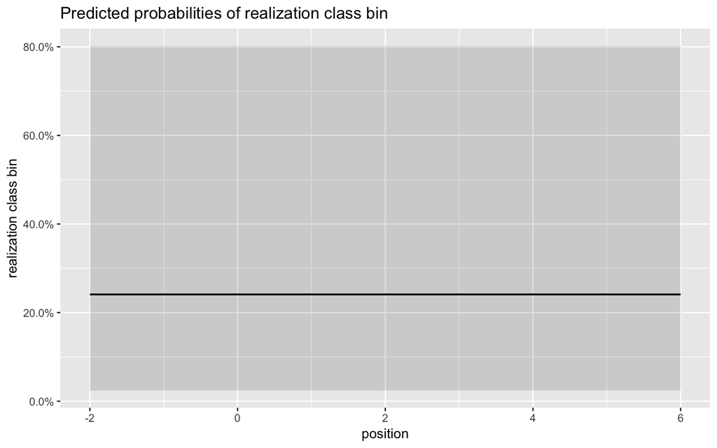

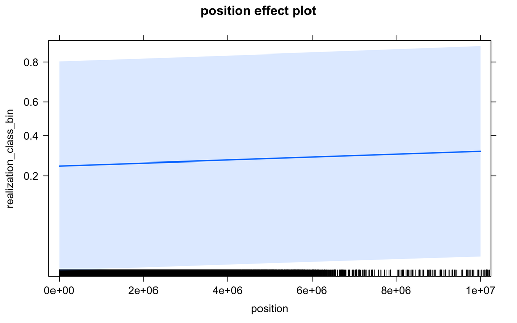

### Variable, gender and position intercation:

```r
model_var <- glmer(realization_class_bin ~ scale(position):var:sex  + (1 | speaker) + (1 | token) + (1 | age_group) + (1 | audio), family = binomial, data=data)
```

```r
model1_sex_pos <- glm(realization_class_bin ~ scale(position):var:sex, data=data, family = binomial)

AIC(model1_sex_pos)
```

```
## [1] 31635.11
```

```r
model2_sex_pos  <- glmer(realization_class_bin ~ scale(position):var:sex + (1 | audio/speaker) + (1 | token)  + (1 | age_group), family = binomial, data=data)

AIC(model2_sex_pos )
```

```
## [1] 20631.91
```

```r
model3_sex_pos  <- glmer(realization_class_bin ~ scale(position):var:sex  + (1 | audio/speaker) + (1 | token)  + (1 | year_of_birth), family = binomial, data=data)

AIC(model3_sex_pos)
```

```
## [1] 20641.02
```

```r
model4_sex_pos <- glmer(realization_class_bin ~ scale(position):var:sex  + (1 | speaker) + (1 | token) + (1 | age_group) + (1 | audio), family = binomial, data=data)

AIC(model4_sex_pos)
```

```
## [1] 20535.91
```

```r
model5_sex_pos <- glmer(realization_class_bin ~ scale(position):var:sex  + (1 | speaker) + (1 | token)  + (1 | year_of_birth) + (1 | audio), family = binomial, data=data)

AIC(model5_sex_pos)
```

```
## [1] 20560.94
```

```r
model6_sex_pos <- glmer(realization_class_bin ~ scale(position):var:sex  + (1 | audio/speaker/year_of_birth) + (1 | token) , family = binomial, data=data)

AIC(model6_sex_pos)
```

```
## [1] 20749.5
```

```r
model7_sex_pos <- glmer(realization_class_bin ~ scale(position):var:sex  + (1 | audio/speaker/age_group) + (1 | token) , family = binomial, data=data)

AIC(model7_sex_pos)
```

```
## [1] 20749.51
```

The results of the best fitted model:

```
## Generalized linear mixed model fit by maximum likelihood (Laplace
##   Approximation) [glmerMod]
##  Family: binomial  ( logit )
## Formula:
## realization_class_bin ~ scale(position):var:sex + (1 | speaker) +
##     (1 | token) + (1 | age_group) + (1 | audio)
##    Data: data
##
##      AIC      BIC   logLik deviance df.resid
##  20535.9  20769.3 -10239.0  20477.9    23053
##
## Scaled residuals:
##     Min      1Q  Median      3Q     Max
## -9.7772 -0.4264  0.0713  0.4054 29.5486
##
## Random effects:
##  Groups    Name        Variance Std.Dev.
##  token     (Intercept) 4.7106   2.1704
##  audio     (Intercept) 0.1316   0.3628
##  speaker   (Intercept) 3.4682   1.8623
##  age_group (Intercept) 3.3761   1.8374
## Number of obs: 23082, groups:
## token, 5132; audio, 168; speaker, 108; age_group, 3
##
## Fixed effects:
##                                        Estimate Std. Error z value
## (Intercept)                            -1.22435    1.08821  -1.125
## scale(position):varadj:sexfemale        0.10595    0.07088   1.495
## scale(position):varae:sexfemale        -0.15396    0.09775  -1.575
## scale(position):vardiss:sexfemale       0.11308    0.12619   0.896
## scale(position):varei:sexfemale        -0.26944    0.10201  -2.641
## scale(position):varone:sexfemale        0.10174    0.11361   0.895
## scale(position):varot:sexfemale        -0.07030    0.13621  -0.516
## scale(position):varprep_pron:sexfemale  0.08928    0.12057   0.740
## scale(position):varsh:sexfemale         0.16374    0.08106   2.020
## scale(position):varsja1:sexfemale      -0.12557    0.10374  -1.210
## scale(position):varsja2:sexfemale       0.16824    0.11110   1.514
## scale(position):vartu:sexfemale        -0.20197    0.15598  -1.295
## scale(position):vartu_acc:sexfemale    -0.86592    1.17354  -0.738
## scale(position):varadj:sexmale         -0.10969    0.13884  -0.790
```

[output cut: 24 more lines]

```
## scale(position):vartu_acc:sexfemale    0.460597
## scale(position):varadj:sexmale         0.429501
## scale(position):varae:sexmale          0.206764
## scale(position):vardiss:sexmale        0.855624
## scale(position):varei:sexmale          0.022884 *
## scale(position):varone:sexmale         0.002128 **
## scale(position):varot:sexmale          0.076254 .
## scale(position):varprep_pron:sexmale   0.401585
## scale(position):varsh:sexmale          0.000105 ***
## scale(position):varsja1:sexmale        0.465808
## scale(position):varsja2:sexmale        0.334891
## scale(position):vartu:sexmale          0.387054
## scale(position):vartu_acc:sexmale      0.420824
## ---
## Signif. codes:  0 '***' 0.001 '**' 0.01 '*' 0.05 '.' 0.1 ' ' 1
```

```
##
## Correlation matrix not shown by default, as p = 25 > 12.
## Use print(x, correlation=TRUE)  or
##     vcov(x)        if you need it
```

```
## convergence code: 0
## Model failed to converge with max|grad| = 0.124085 (tol = 0.001, component 1)
## failure to converge in 10000 evaluations
```

Effects plot:

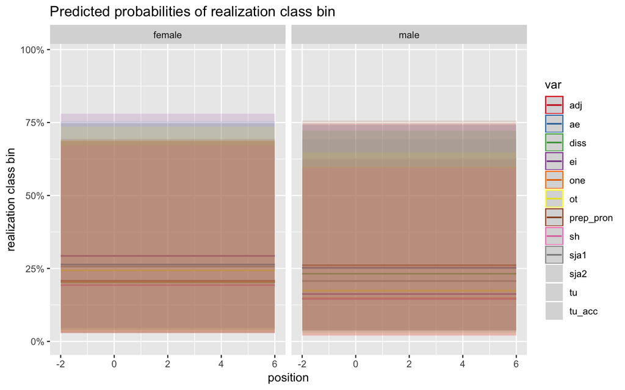

### Gender and position interaction:

```r
model1_sex <- glm(realization_class_bin ~ scale(position):sex, data=data, family = binomial)

AIC(model1_sex)
```

```
## [1] 31833.94
```

```r
model2_sex <- glmer(realization_class_bin ~ scale(position):sex + (1 | audio/speaker) + (1 | token/var)  + (1 | age_group), family = binomial, data=data)

AIC(model2_sex)
```

```
## [1] 20448.16
```

```r
model3_sex <- glmer(realization_class_bin ~ scale(position):sex  + (1 | audio/speaker) + (1 | token/var)  + (1 | year_of_birth), family = binomial, data=data)

AIC(model3_sex)
```

```
## [1] 20457.59
```

```r
model4_sex <- glmer(realization_class_bin ~ scale(position):sex  + (1 | speaker) + (1 | token/var)  + (1 | age_group) + (1 | audio), family = binomial, data=data)

AIC(model4_sex)
```

```
## [1] 20354.07
```

```r
model5_sex <- glmer(realization_class_bin ~ scale(position):sex  + (1 | speaker) + (1 | token/var)  + (1 | year_of_birth) + (1 | audio), family = binomial, data=data)

AIC(model5_sex)
```

```
## [1] 20380.06
```

```r
model6_sex <- glmer(realization_class_bin ~ scale(position):sex  + (1 | audio/speaker/year_of_birth) + (1 | token/var) , family = binomial, data=data)

AIC(model6_sex)
```

```
## [1] 20570.95
```

```r
model7_sex <- glmer(realization_class_bin ~ scale(position):sex  + (1 | audio/speaker/age_group) + (1 | token/var) , family = binomial, data=data)

AIC(model7_sex)
```

```
## [1] 20570.95
```

Summary of the best model (4th):

```
## Generalized linear mixed model fit by maximum likelihood (Laplace
##   Approximation) [glmerMod]
##  Family: binomial  ( logit )
## Formula: realization_class_bin ~ scale(position):sex + (1 | speaker) +
##     (1 | token/var) + (1 | age_group) + (1 | audio)
##    Data: data
##
##      AIC      BIC   logLik deviance df.resid
##  20354.1  20418.4 -10169.0  20338.1    23074
##
## Scaled residuals:
##      Min       1Q   Median       3Q      Max
## -10.3542  -0.4105   0.0907   0.3918  31.4181
##
## Random effects:
##  Groups    Name        Variance  Std.Dev.
##  var:token (Intercept) 5.511e+00 2.3475072
##  token     (Intercept) 1.179e-08 0.0001086
##  audio     (Intercept) 1.457e-01 0.3817483
##  speaker   (Intercept) 3.419e+00 1.8490337
##  age_group (Intercept) 3.523e+00 1.8770409
## Number of obs: 23082, groups:
## var:token, 5459; token, 5132; audio, 168; speaker, 108; age_group, 3
##
## Fixed effects:
##                           Estimate Std. Error z value Pr(>|z|)
## (Intercept)               -1.24761    1.10278  -1.131  0.25792
## scale(position):sexfemale  0.02169    0.03508   0.618  0.53642
## scale(position):sexmale    0.12313    0.04536   2.715  0.00663 **
## ---
## Signif. codes:  0 '***' 0.001 '**' 0.01 '*' 0.05 '.' 0.1 ' ' 1
##
## Correlation of Fixed Effects:
##               (Intr) scl(pstn):sxf
## scl(pstn):sxf 0.002
## scl(pstn):sxm 0.004  0.012
```

Plot of the results:

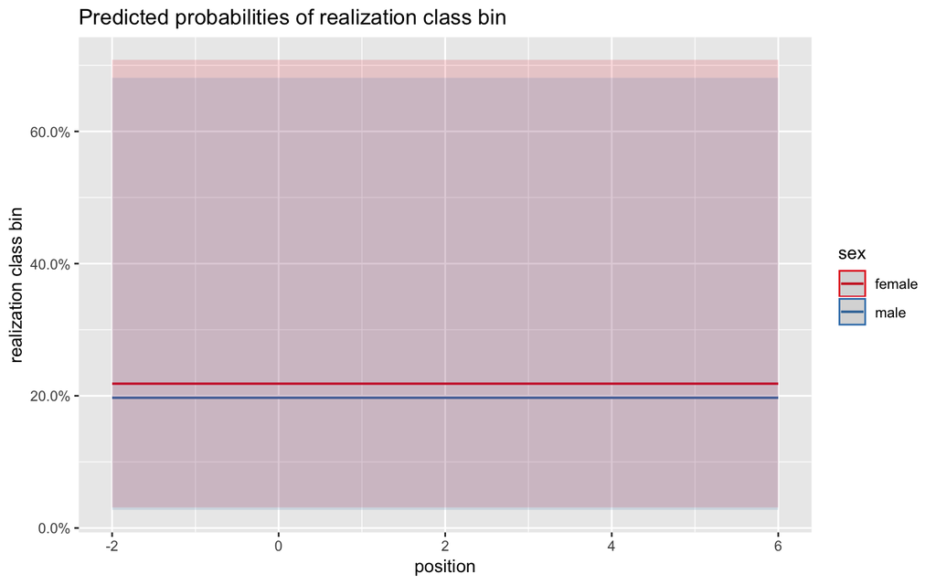

### Position and age-group interaction:

```r
model4_year <- glmer(realization_class_bin ~ scale(position):age_group:sex  + (1 | speaker) + (1 | token) + (1 | var) + (1 | audio), family = binomial, data=data)

AIC(model4_year)
```

```
## [1] 17917.37
```

```r
summary(model4_year)
```

```
## Generalized linear mixed model fit by maximum likelihood (Laplace
##   Approximation) [glmerMod]
##  Family: binomial  ( logit )
## Formula: realization_class_bin ~ scale(position):age_group:sex + (1 |
##     speaker) + (1 | token) + (1 | var) + (1 | audio)
##    Data: data
##
##      AIC      BIC   logLik deviance df.resid
##  17917.4  18005.9  -8947.7  17895.4    23071
##
## Scaled residuals:
##     Min      1Q  Median      3Q     Max
## -11.589  -0.397   0.076   0.365  37.888
##
## Random effects:
##  Groups  Name        Variance Std.Dev.
##  token   (Intercept) 1.3069   1.1432
##  audio   (Intercept) 0.1137   0.3372
##  speaker (Intercept) 6.8838   2.6237
##  var     (Intercept) 2.9573   1.7197
## Number of obs: 23082, groups:
## token, 5132; audio, 168; speaker, 108; var, 12
##
## Fixed effects:
##                                              Estimate Std. Error z value
## (Intercept)                                  -0.55786    0.56841  -0.981
## scale(position):age_group< 1940:sexfemale    -0.03076    0.04847  -0.635
## scale(position):age_group> 1960:sexfemale    -0.02302    0.10789  -0.213
## scale(position):age_group1940-1960:sexfemale  0.02921    0.05218   0.560
## scale(position):age_group< 1940:sexmale       0.13052    0.05976   2.184
## scale(position):age_group> 1960:sexmale       0.01213    0.12764   0.095
## scale(position):age_group1940-1960:sexmale    0.06714    0.07293   0.921
##                                              Pr(>|z|)
## (Intercept)                                     0.326
## scale(position):age_group< 1940:sexfemale       0.526
## scale(position):age_group> 1960:sexfemale       0.831
## scale(position):age_group1940-1960:sexfemale    0.576
## scale(position):age_group< 1940:sexmale         0.029 *
## scale(position):age_group> 1960:sexmale         0.924
## scale(position):age_group1940-1960:sexmale      0.357
```

[output cut: 24 more lines]

```
## scl(pstn):g_grp1940-1960:sxm -0.006
##                              scl(pstn):g_grp<1940:sxm
## scl(pstn):g_grp<1940:sxf
## scl(pstn):g_grp>1960:sxf
## scl(pstn):g_grp1940-1960:sxf
## scl(pstn):g_grp<1940:sxm
## scl(pstn):g_grp>1960:sxm     -0.008
## scl(pstn):g_grp1940-1960:sxm  0.001
##                              scl(pstn):g_grp>1960:sxm
## scl(pstn):g_grp<1940:sxf
## scl(pstn):g_grp>1960:sxf
## scl(pstn):g_grp1940-1960:sxf
## scl(pstn):g_grp<1940:sxm
## scl(pstn):g_grp>1960:sxm
## scl(pstn):g_grp1940-1960:sxm  0.002
```